# eda_analytics_cup

Manuel Schreiber

**UPDATES**

**January 11: payments.csv file from training data updated**

**January 20: hints from coaching session:** split 5000 data points into train and evaluation set (e.g. 4000/1000) -> then train the model again using all 5000 data points before making the predition on the test features belonging to the hidden target variables

Plot categorical features and computing a correlation matrix for numerical variables to detect correlations/find useful features

**Task**

Predict Ownership Interests of physicians in pharmaceutical companies from regulatory transaction data.

**Task description:**

You are given 1 400 000 instances of transactions which have been received by 6000 physicians in the years 2013 to 2019 (transactions.csv), as well as additional data about these doctors (physicians.csv) and companies (companies.csv). For 5000 of these doctors, transactions related to ownership interest (if any) are included, for the other 1000 (the test set), these kinds of transactions have been removed from the transaction data. For each of these 1000 physicians, your model must make a prediction about whether they have had such ownership interests (prediction=1) or not (prediction=0).

```r
# clear workspace
##rm(list=ls())
```

```r
# Loading Packages

library(tidyverse) # collection of packages for data analysis including: ggplot2 (data visualization package), dplyr (data manipulation package), tidyr, readr (faster read.csv() functions that create tibble objects instead of data.frames), purrr, tibble (wrapper around data.frames for better printing), stringr, forcats
library(lubridate) # tools to parse and manipulate dates
library(GGally) # ggplot2 extension (for a heat map plot)
library(graphics) # base graphics (e.g. histogram)

library(stats) # computing distribution functions, distribution quantiles; random number generation


library(tidymodels) # collection of packages for modeling and machine learning
library(googledrive) # interface to googledrive
library(descr) # crosstab function for EDA

library(mltools) # one hot encoding function
library(data.table)
# obtaining your current working directory
getwd()
```

```
## [1] "/Users/Manu/Desktop/TUM_Master_Mgt_Technology/TUM_WS_20/Business Analytics/Analytics Cup"
```

```r
# finds all CSV files on your google drive
##drive_find(type = "csv")

# downloading a file from Gdrive to your working directory
##drive_download("water_qual.csv", overwrite = TRUE)

# uploading a file to Gdrive
##drive_upload()

# updating a file on Gdrive
##drive_update()

# deleting files on Gdrive
##drive_rm()
```

```r
##drive_download("physicians.csv")
#drive_download("payments.csv", overwrite = TRUE)
```

# Exploratory Data Analysis

## Physicians dataframe

```r
physicians_df <- read_delim("physicians.csv", delim = ",")
str(physicians_df)
```

```
## tibble [6,000 × 17] (S3: spec_tbl_df/tbl_df/tbl/data.frame)
##  $ id               : num [1:6000] 1 2 3 4 5 6 7 8 9 10 ...
##  $ set              : chr [1:6000] "train" "train" "train" "train" ...
##  $ First_Name       : chr [1:6000] "LEIGH" "STEVEN" "THOMAS" "CLAUDE" ...
##  $ Middle_Name      : chr [1:6000] "B" NA NA NA ...
##  $ Last_Name        : chr [1:6000] "HOPPE" "FRANK" "COUCH" "SU" ...
##  $ Name_Suffix      : chr [1:6000] NA NA "JR." NA ...
##  $ City             : chr [1:6000] "FORT PIERCE" "TOWSON" "TROY" "SAVANNAH" ...
##  $ State            : chr [1:6000] "FL" "MD" "NY" "GA" ...
##  $ Zipcode          : chr [1:6000] "34950" "21204-6808" "12180-2832" "31419-1753" ...
##  $ Country          : chr [1:6000] "UNITED STATES" "UNITED STATES" "UNITED STATES" "UNITED STATES" ...
##  $ Province         : logi [1:6000] NA NA NA NA NA NA ...
##  $ Primary_Specialty: chr [1:6000] "Allopathic & Osteopathic Physicians|Obstetrics & Gynecology|Gynecology" "Allopathic & Osteopathic Physicians|Anesthesiology" "Podiatric Medicine & Surgery Service Providers|Podiatrist" "Allopathic & Osteopathic Physicians|Internal Medicine|Cardiovascular Diseas…
##  $ License_State_1  : chr [1:6000] "FL" "MD" "NY" "GA" ...
##  $ License_State_2  : chr [1:6000] NA NA NA "SC" ...
##  $ License_State_3  : chr [1:6000] NA NA NA "AL" ...
##  $ License_State_4  : chr [1:6000] NA NA NA NA ...
##  $ License_State_5  : chr [1:6000] NA NA NA NA ...
##  - attr(*, "spec")=
##   .. cols(
##   ..   id = col_double(),
##   ..   set = col_character(),
##   ..   First_Name = col_character(),
##   ..   Middle_Name = col_character(),
##   ..   Last_Name = col_character(),
##   ..   Name_Suffix = col_character(),
##   ..   City = col_character(),
##   ..   State = col_character(),
##   ..   Zipcode = col_character(),
##   ..   Country = col_character(),
##   ..   Province = col_logical(),
##   ..   Primary_Specialty = col_character(),
##   ..   License_State_1 = col_character(),
##   ..   License_State_2 = col_character(),
##   ..   License_State_3 = col_character(),
##   ..   License_State_4 = col_character(),
##   ..   License_State_5 = col_character()
##   .. )
```

```r
head(physicians_df)
```

| id | set | First_Name | Middle_Name | Last_Name | Name_Suffix | City | State | Zipcode | Country | Province | Primary_Specialty | License_State_1 | License_State_2 | License_State_3 | License_State_4 | License_State_5 |
| --- | --- | --- | --- | --- | --- | --- | --- | --- | --- | --- | --- | --- | --- | --- | --- | --- |
| 1 | train | LEIGH | B | HOPPE | NA | FORT PIERCE | FL | 34950 | UNITED STATES | NA | Allopathic & Osteopathic Physicians\|Obstetrics & Gynecology\|Gynecology | FL | NA | NA | NA | NA |
| 2 | train | STEVEN | NA | FRANK | NA | TOWSON | MD | 21204-6808 | UNITED STATES | NA | Allopathic & Osteopathic Physicians\|Anesthesiology | MD | NA | NA | NA | NA |
| 3 | train | THOMAS | NA | COUCH | JR. | TROY | NY | 12180-2832 | UNITED STATES | NA | Podiatric Medicine & Surgery Service Providers\|Podiatrist | NY | NA | NA | NA | NA |
| 4 | train | CLAUDE | NA | SU | NA | SAVANNAH | GA | 31419-1753 | UNITED STATES | NA | Allopathic & Osteopathic Physicians\|Internal Medicine\|Cardiovascular Disease | GA | SC | AL | NA | NA |
| 5 | train | ROBERT | C | SCHENCK | NA | ALBUQUERQUE | NM | 87131-0001 | UNITED STATES | NA | Allopathic & Osteopathic Physicians\|Orthopaedic Surgery\|Sports Medicine | NM | NA | NA | NA | NA |
| 6 | train | ARNOLD | NA | TYRANGEL | NA | BAYSIDE | NY | 11360-2019 | UNITED STATES | NA | Dental Providers\|Dentist\|General Practice | NY | NA | NA | NA | NA |

```r
# interesting features: id -> way to join with payments df
```

```r
# finding the number of NA values by column in the physicians df
physicians_df %>% mutate_all(is.na) %>% summarize_all(sum)
```

| id | set | First_Name | Middle_Name | Last_Name | Name_Suffix | City | State | Zipcode | Country | Province | Primary_Specialty | License_State_1 | License_State_2 | License_State_3 | License_State_4 | License_State_5 |
| --- | --- | --- | --- | --- | --- | --- | --- | --- | --- | --- | --- | --- | --- | --- | --- | --- |
| 0 | 0 | 1 | 1655 | 2 | 5827 | 0 | 1 | 0 | 0 | 6000 | 258 | 0 | 3954 | 5357 | 5808 | 5952 |

```r
# all colnames
colnames(physicians_df)
```

```
##  [1] "id"                "set"               "First_Name"
##  [4] "Middle_Name"       "Last_Name"         "Name_Suffix"
##  [7] "City"              "State"             "Zipcode"
## [10] "Country"           "Province"          "Primary_Specialty"
## [13] "License_State_1"   "License_State_2"   "License_State_3"
## [16] "License_State_4"   "License_State_5"
```

```r
# reduced dataframe -: removing variables
physicians_df_red <- subset(physicians_df, select = -c(First_Name,Middle_Name,Last_Name, Name_Suffix))


# # storing all physician id's for the training set
# id_train <- physicians_df_red$id[physicians_df_red$set=="train"]
#
# # storing all physician id's for the test set
# id_test <- physicians_df_red$id[physicians_df_red$set=="test"]
#
#
```

```r
#crosstab(dep = physicians_df$id, indep = physicians_df$Primary_Specialty)
```

## payments dataframe

```r
payments_df <- read_delim("payments.csv", delim = ",")
str(payments_df)
```

```
## tibble [1,402,250 × 29] (S3: spec_tbl_df/tbl_df/tbl/data.frame)
##  $ Record_ID                             : num [1:1402250] 1 2 3 4 5 6 7 8 9 10 ...
##  $ Physician_ID                          : num [1:1402250] 2455 1534 2632 550 1710 ...
##  $ Company_ID                            : num [1:1402250] 597 593 760 760 826 145 115 897 115 74 ...
##  $ Total_Amount_of_Payment_USDollars     : num [1:1402250] 48.8 122.4 10.3 13.7 17.2 ...
##  $ Date                                  : chr [1:1402250] "08/01/2013" "08/01/2013" "08/01/2013" "08/01/2013" ...
##  $ Number_of_Payments                    : num [1:1402250] 1 1 1 1 1 1 1 1 1 1 ...
##  $ Form_of_Payment_or_Transfer_of_Value  : chr [1:1402250] "In-kind items and services" "In-kind items and services" "In-kind items and services" "In-kind items and services" ...
##  $ Nature_of_Payment_or_Transfer_of_Value: chr [1:1402250] "Food and Beverage" "Food and Beverage" "Education" "Education" ...
##  $ City_of_Travel                        : chr [1:1402250] NA NA NA NA ...
##  $ State_of_Travel                       : chr [1:1402250] NA NA NA NA ...
##  $ Country_of_Travel                     : chr [1:1402250] NA NA NA NA ...
##  $ Ownership_Indicator                   : chr [1:1402250] "No" "No" "No" "No" ...
##  $ Third_Party_Recipient                 : chr [1:1402250] "No Third Party Payment" "No Third Party Payment" "No Third Party Payment" "No Third Party Payment" ...
##  $ Charity                               : chr [1:1402250] NA "No" NA NA ...
##  $ Third_Party_Covered                   : chr [1:1402250] NA NA NA NA ...
##  $ Contextual_Information                : chr [1:1402250] NA NA NA NA ...
##  $ Related_Product_Indicator             : chr [1:1402250] "Covered" "Covered" "Covered" "Covered" ...
##  $ Product_Code_1                        : chr [1:1402250] NA "1529370001" NA NA ...
##  $ Product_Code_2                        : chr [1:1402250] NA NA NA NA ...
##  $ Product_Code_3                        : chr [1:1402250] NA NA NA NA ...
##  $ Product_Type_1                        : chr [1:1402250] "Device or Medical Supply" "Drug or Biological" "Drug or Biological" "Drug or Biological" ...
##  $ Product_Type_2                        : chr [1:1402250] NA NA NA NA ...
##  $ Product_Type_3                        : chr [1:1402250] NA NA NA NA ...
##  $ Product_Name_1                        : chr [1:1402250] "Pacemakers" "Vascepa" "ACTHAR" "ACTHAR" ...
##  $ Product_Name_2                        : chr [1:1402250] NA NA NA NA ...
##  $ Product_Name_3                        : chr [1:1402250] NA NA NA NA ...
##  $ Product_Category_1                    : logi [1:1402250] NA NA NA NA NA NA ...
##  $ Product_Category_2                    : logi [1:1402250] NA NA NA NA NA NA ...
##  $ Product_Category_3                    : logi [1:1402250] NA NA NA NA NA NA ...
##  - attr(*, "problems")= tibble [1,056,764 × 5] (S3: tbl_df/tbl/data.frame)
##   ..$ row     : int [1:1056764] 531058 531059 531059 531060 531062 531063 531063 531064 531064 531065 ...
##   ..$ col     : chr [1:1056764] "Product_Category_1" "Product_Category_1" "Product_Category_2" "Product_Category_1" ...
##   ..$ expected: chr [1:1056764] "1/0/T/F/TRUE/FALSE" "1/0/T/F/TRUE/FALSE" "1/0/T/F/TRUE/FALSE" "1/0/T/F/TRUE/FALSE" ...
##   ..$ actual  : chr [1:1056764] "OPHTHALMOLOGY" "Orthopaedics" "Orthopaedics" "Electromedical and Electrotherapeutic Apparatus" ...
##   ..$ file    : chr [1:1056764] "'payments.csv'" "'payments.csv'" "'payments.csv'" "'payments.csv'" ...
##  - attr(*, "spec")=
##   .. cols(
##   ..   Record_ID = col_double(),
##   ..   Physician_ID = col_double(),
```

[output cut: 13 more lines]

```
##   ..   Contextual_Information = col_character(),
##   ..   Related_Product_Indicator = col_character(),
##   ..   Product_Code_1 = col_character(),
##   ..   Product_Code_2 = col_character(),
##   ..   Product_Code_3 = col_character(),
##   ..   Product_Type_1 = col_character(),
##   ..   Product_Type_2 = col_character(),
##   ..   Product_Type_3 = col_character(),
##   ..   Product_Name_1 = col_character(),
##   ..   Product_Name_2 = col_character(),
##   ..   Product_Name_3 = col_character(),
##   ..   Product_Category_1 = col_logical(),
##   ..   Product_Category_2 = col_logical(),
##   ..   Product_Category_3 = col_logical()
##   .. )
```

```r
# interesting features. Physician_ID, Company_ID, Ownership_Indicator
```

*Plotting categorical features and computing a correlation matrix for numerical variables*

```r
# correlation matrix of numerical features
cor(select(payments_df, where(is.numeric)))
```

```
##                                       Record_ID  Physician_ID   Company_ID
## Record_ID                          1.0000000000 -0.0049256187  0.141562064
## Physician_ID                      -0.0049256187  1.0000000000 -0.007201593
## Company_ID                         0.1415620640 -0.0072015928  1.000000000
## Total_Amount_of_Payment_USDollars  0.0002801795  0.0003512593  0.005694654
## Number_of_Payments                -0.0074025799 -0.0015633155 -0.007207364
##                                   Total_Amount_of_Payment_USDollars
## Record_ID                                              0.0002801795
## Physician_ID                                           0.0003512593
## Company_ID                                             0.0056946535
## Total_Amount_of_Payment_USDollars                      1.0000000000
## Number_of_Payments                                     0.0023322027
##                                   Number_of_Payments
## Record_ID                               -0.007402580
## Physician_ID                            -0.001563316
## Company_ID                              -0.007207364
## Total_Amount_of_Payment_USDollars        0.002332203
## Number_of_Payments                       1.000000000
```

correlations worth looking at: Company_ID - Record_Id

```r
# barplot of the frequency table of the categorical feature "Country of Travel"
table(payments_df$Ownership_Indicator, payments_df$Country_of_Travel)
```

```
##
##       Algeria Argentina Aruba Australia Austria Bahamas Bahrain Barbados
##   No        1        26    10        57      37       1       4        1
##   Yes       0         3     0         0       0       0       0        0
##
##       Belgium Brazil Canada Chile China Colombia Costa Rica Czech Republic
##   No       19     61    239     7   116       45          2             14
##   Yes       0      1      1     0     0        0          0              0
##
##       Denmark Dominican Republic Egypt Finland France Georgia Germany
##   No       78                  4    10      11    142       7     231
##   Yes       0                  0     0       0      3       0       3
##
##       Great Britain (Uk) Greece Hong Kong Hungary Iceland India Indonesia
##   No                 208      9         2      10       3    30         8
##   Yes                  0      0         0       0       0     0         0
##
##       Ireland Israel Italy Japan Jordan Korea (Democratic People's Republic of)
##   No       80     13    62   126      2                                       3
##   Yes       0      0     0     0      0                                       0
##
##       Korea (Republic of) Lebanon Malaysia Mexico Namibia Netherlands
##   No                   29       3       18     59       2          77
##   Yes                   0       0        0      0       0           0
##
##       Netherlands Antilles New Zealand Norway Panama  Peru Philippines Poland
##   No                     3           1      1     14     1           3      2
##   Yes                    0           0      0      0     0           0      1
##
##       Portugal Russian Federation Saudi Arabia Singapore Spain Sweden
##   No        21                  3            3        33   164     34
##   Yes        0                  0            0         0     3      0
##
##       Switzerland Taiwan Thailand Turkey United Arab Emirates United States
##   No          118     11        5      8                   14         72583
##   Yes           1      0        0      0                    0           221
##
##       Vietnam
##   No        2
##   Yes       0
```

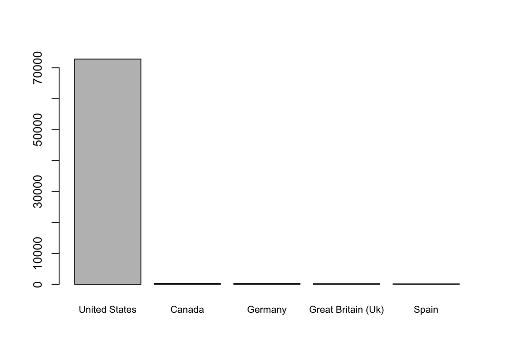

```r
# plotting the top 5 most frequent values of the categorical feature Country of Travel
barplot(sort(table(payments_df$Country_of_Travel), decreasing = TRUE)[1:5], cex.names = 0.8)
```

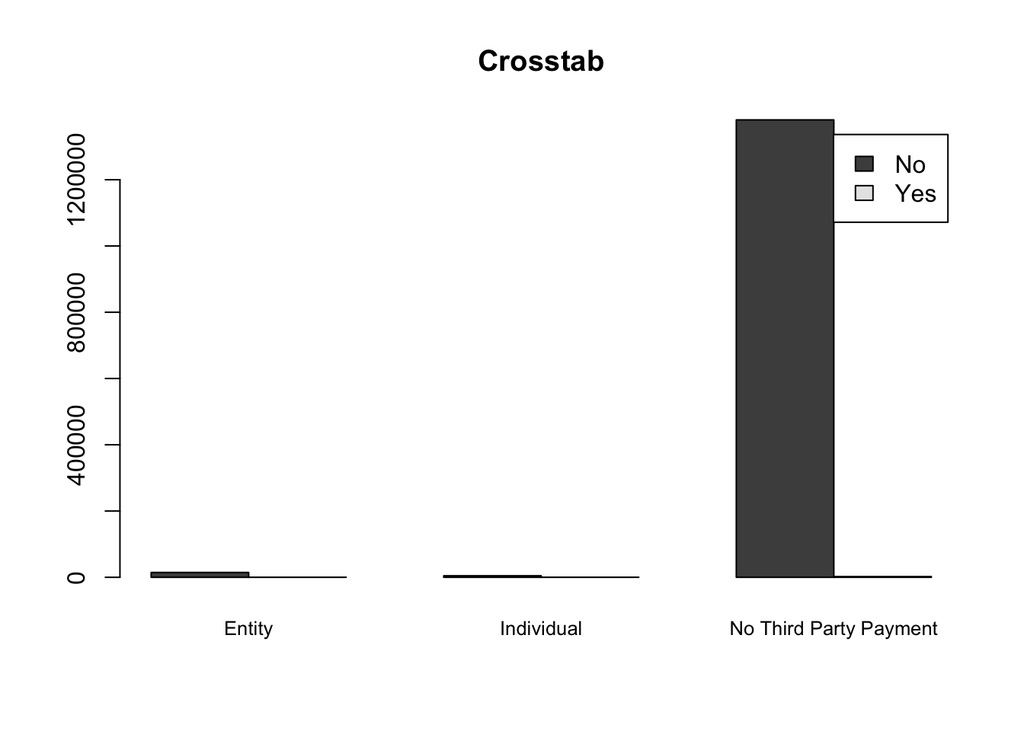

```r
# cross tab plot of ownership interest and certain features with legend
barplot(with(payments_df, table(Ownership_Indicator, Third_Party_Recipient, exclude = "NA")), beside = TRUE, legend.text = TRUE, main = "Crosstab", cex.names = 0.8)
```

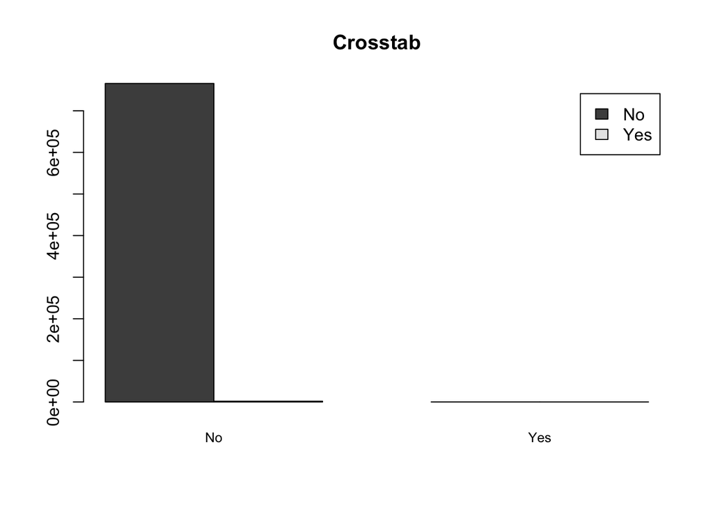

```r
# cross tab plot of ownership interest and certain features with legend
barplot(with(payments_df, table(Ownership_Indicator, Charity)), beside = TRUE, legend.text = TRUE, main = "Crosstab", cex.names = 0.8)
```

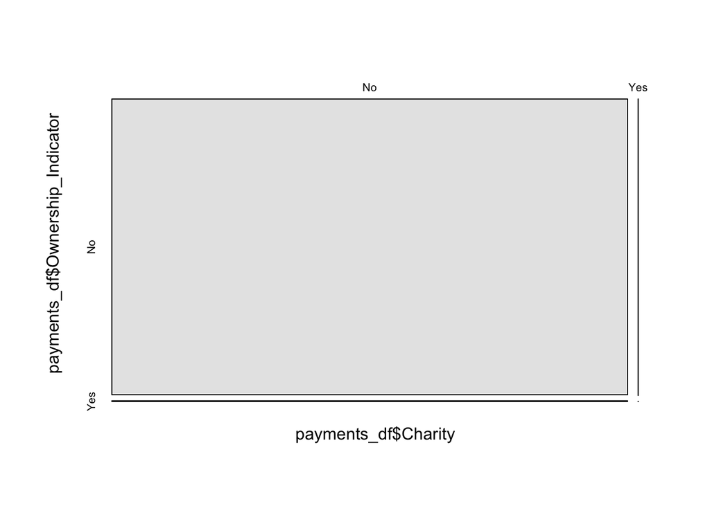

```
##    Cell Contents
## |-------------------------|
## |                   Count |
## |-------------------------|
##
## ========================================================
##                                    payments_df$Charity
## payments_df$Ownership_Indicator        No   Yes    Total
## --------------------------------------------------------
## No                                 7.657e+05    27   7.657e+05
## --------------------------------------------------------
## Yes                                  1823     0     1823
## --------------------------------------------------------
## Total                              7.675e+05    27   7.675e+05
## ========================================================
```

```r
# cross tab plot (way 2)
crosstab(dep=payments_df$Ownership_Indicator, indep= payments_df$Charity)
```

```r
# cross table
with(payments_df, table(Ownership_Indicator, Charity))
```

```
##                    Charity
## Ownership_Indicator     No    Yes
##                 No  765679     27
##                 Yes   1823      0
```

```r
# Cross table of the values of the categorical feature State of Travel and ownership
table(payments_df$Ownership_Indicator, payments_df$State_of_Travel)
```

```
##
##         AK   AL   AR   AZ   CA   CO   CT   DC   DE   FL   GA   HI   IA   ID
##   No    77  566  375 2414 9615 1477  796  687  137 8403 2796  202  231  159
##   Yes    0    1    0   24   36    7    0    1    0   15   20    0    0    0
##
##         IL   IN   KS   KY   LA   MA   MD   ME   MI   MN   MO   MS   MT   NC
##   No  5187  718  401  289 1354 1830  837  125 1149 1828  779  389   97 1335
##   Yes   11    2    0    3    4    7    1    0    0    9    5    0    0    9
##
##         ND   NE   NH   NJ   NM   NV   NY   OH   OK   OR   PA   PR   RI   SC
##   No    45  313  108 2302  182 1879 4501 1208  500  623 2679   84  116  611
##   Yes    0    0    0    4    1    2    3    3    2    8    9    0    0    0
##
##         SD   TN   TX   UT   VA   VT   WA   WI   WV   WY
##   No   104 1462 8510  447 1128   11  903  517   67   30
##   Yes    0    3   29    0    1    0    0    0    1    0
```

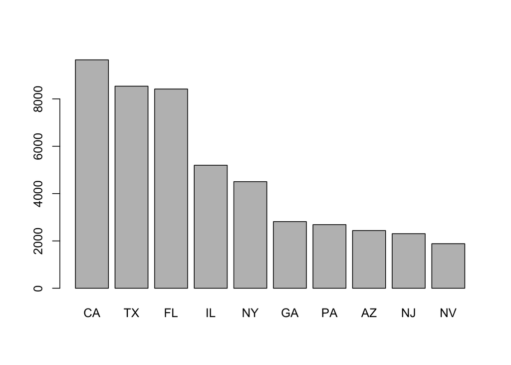

```r
# plotting the top 10 most frequent values of the categorical feature State of Travel
barplot(sort(table(payments_df$State_of_Travel), decreasing = TRUE)[1:10])
```

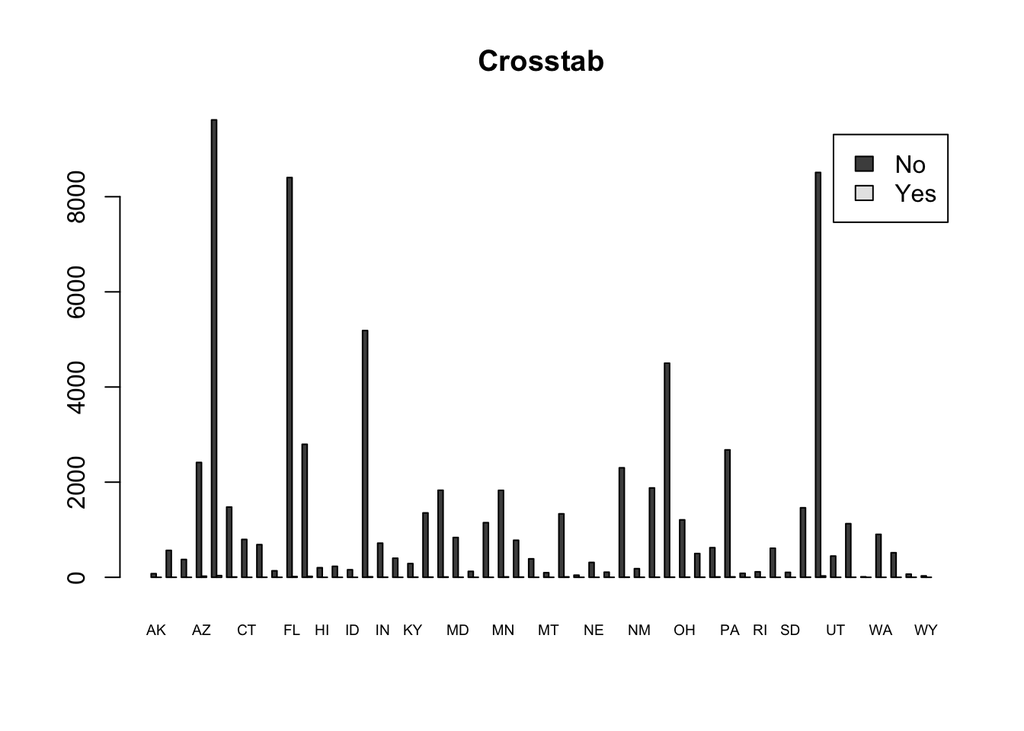

```r
# cross tab plot of ownership interest and certain features with legend
# horiz: if T, bars are drawn horizontally, if F, bars are drawn vertically
barplot(with(payments_df, table(Ownership_Indicator, State_of_Travel)), beside = TRUE, legend.text = TRUE, main = "Crosstab", cex.names = 0.6, horiz=F)
```

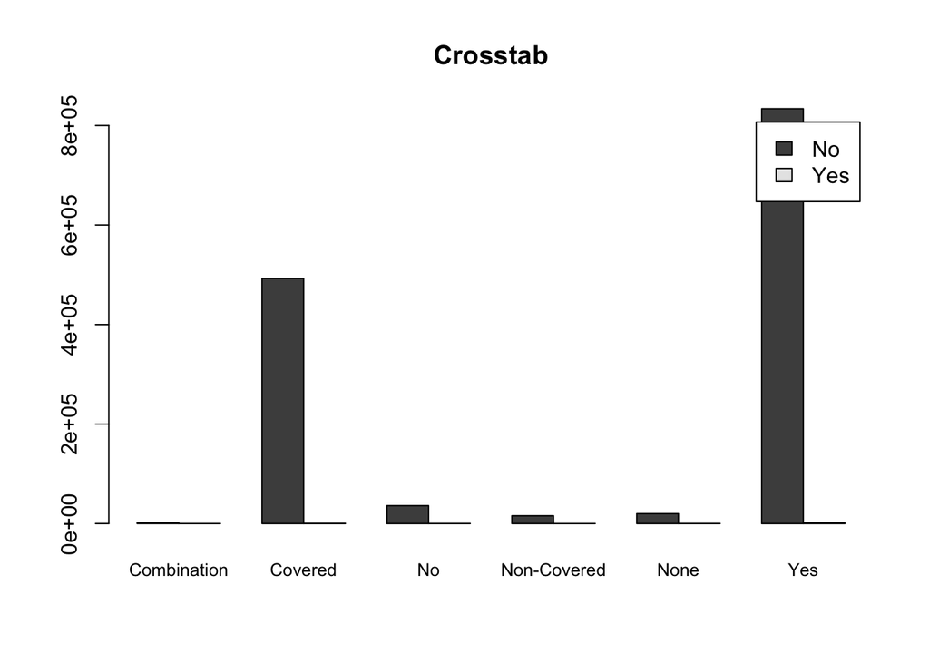

```r
# cross tab plot of ownership interest and certain features with legend
# cex.names: expansion factor for the axis labels
barplot(with(payments_df, table(Ownership_Indicator, Related_Product_Indicator, exclude = "NA")), beside = TRUE, legend.text = TRUE, main = "Crosstab", cex.names = 0.8)
```

```r
print(unique(payments_df$Related_Product_Indicator))
```

```
## [1] "Covered"     "Non-Covered" "Combination" "None"        "No"
## [6] "Yes"
```

```r
# Cross table of the values of the categorical feature Realted_Product_Indicator and ownership
table(payments_df$Ownership_Indicator, payments_df$Related_Product_Indicator)
```

```
##
##       Combination Covered     No Non-Covered   None    Yes
##   No         1795  492697  35970       15749  19987 833648
##   Yes          45     559    190           1    225   1384
```

One-hot encoding is the process of converting a categorical variable with multiple categories into multiple variables, each with a value of 1 or 0.

```r
# Cross table of the values of the categorical feature Transfer of Value and ownership
table(payments_df$Ownership_Indicator, payments_df$Form_of_Payment_or_Transfer_of_Value)
```

```
##
##       Any other ownership interest Cash or cash equivalent
##   No                             0                  230695
##   Yes                            4                    1272
##
##       Dividend, profit or other return on investment In-kind items and services
##   No                                               0                    1169151
##   Yes                                             38                       1070
##
##         Stock Stock option Stock, stock option, or any other ownership interest
##   No        0            0                                                    0
##   Yes      13            3                                                    4
```

```r
unique(payments_df$Form_of_Payment_or_Transfer_of_Value)
```

```
## [1] "In-kind items and services"
## [2] "Cash or cash equivalent"
## [3] "Dividend, profit or other return on investment"
## [4] "Stock, stock option, or any other ownership interest"
## [5] "Any other ownership interest"
## [6] "Stock"
## [7] "Stock option"
```

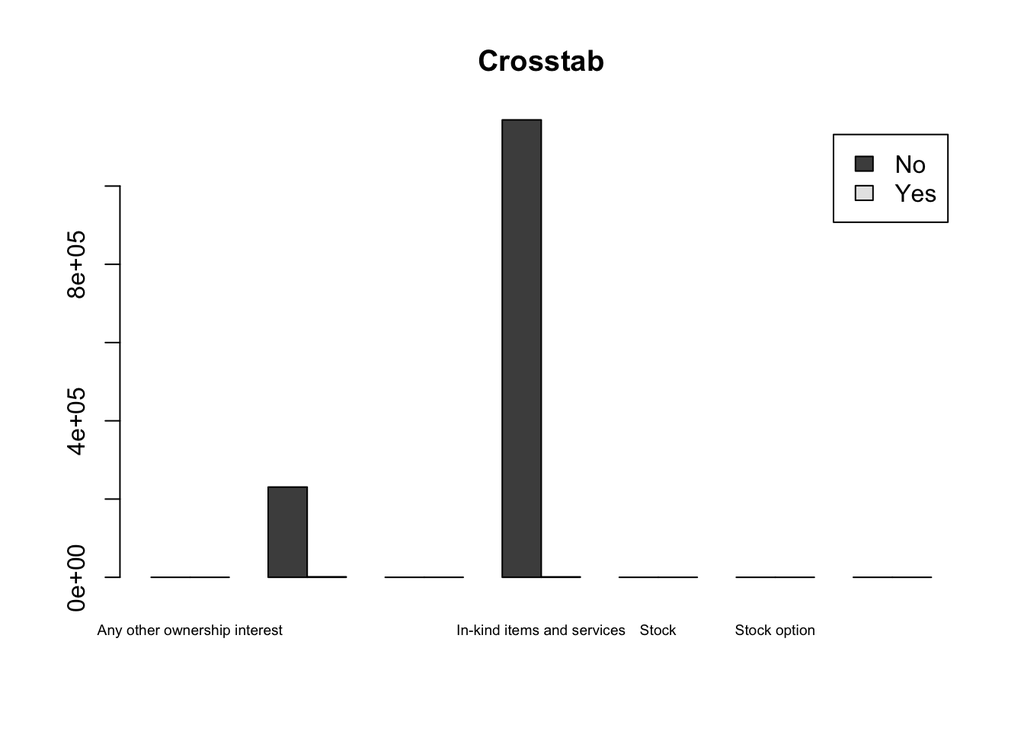

```r
# cross tab plot of ownership interest and certain features with legend
# cex.names: expansion factor for the axis labels
barplot(with(payments_df, table(Ownership_Indicator, Form_of_Payment_or_Transfer_of_Value)), beside = TRUE, legend.text = TRUE, main = "Crosstab", cex.names = 0.6)
```

```r
# one hot encoding of the 7 categories

##oh_df <- payments_df$Physician_ID

##oh_df$form_of_payment <- factor(payments_df$Form_of_Payment_or_Transfer_of_Value)

##new_data <- one_hot(as.data.table(oh_df))

##str(new_data)
```

```r
# unique values (14 in this case)
unique(payments_df$Nature_of_Payment_or_Transfer_of_Value)
```

```
##  [1] "Food and Beverage"
##  [2] "Education"
##  [3] "Consulting Fee"
##  [4] "Compensation for services other than consulting, including serving as faculty or as a speaker at a venue other than a continuing education program"
##  [5] "Gift"
##  [6] "Entertainment"
##  [7] "Travel and Lodging"
##  [8] "Compensation for serving as faculty or as a speaker for a non-accredited and noncertified continuing education program"
##  [9] "Royalty or License"
## [10] "Honoraria"
## [11] "Grant"
## [12] "Current or prospective ownership or investment interest"
## [13] "Compensation for serving as faculty or as a speaker for an accredited or certified continuing education program"
## [14] "Charitable Contribution"
```

```r
# cross table
table(payments_df$Ownership_Indicator,payments_df$Nature_of_Payment_or_Transfer_of_Value)
```

```
##
##       Charitable Contribution
##   No                       39
##   Yes                       1
##
##       Compensation for services other than consulting, including serving as faculty or as a speaker at a venue other than a continuing education program
##   No                                                                                                                                               34791
##   Yes                                                                                                                                                268
##
##       Compensation for serving as faculty or as a speaker for a non-accredited and noncertified continuing education program
##   No                                                                                                                    1471
##   Yes                                                                                                                      0
##
##       Compensation for serving as faculty or as a speaker for an accredited or certified continuing education program
##   No                                                                                                              302
##   Yes                                                                                                               0
##
##       Consulting Fee Current or prospective ownership or investment interest
##   No           18068                                                       0
##   Yes            136                                                     177
##
##       Education Entertainment Food and Beverage    Gift   Grant Honoraria
##   No      30425           702           1229471    4755     228      3168
##   Yes        49             4              1416      54       0         6
##
##       Royalty or License Travel and Lodging
##   No                1484              74942
##   Yes                 56                237
```

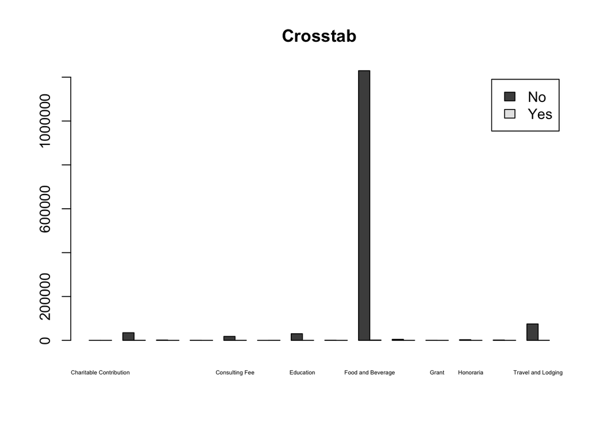

```r
# cross tab plot of ownership interest and certain features with legend
# cex.names: expansion factor for the axis labels
barplot(with(payments_df, table(Ownership_Indicator, Nature_of_Payment_or_Transfer_of_Value)), beside = TRUE, legend.text = TRUE, main = "Crosstab", cex.names = 0.4)
```

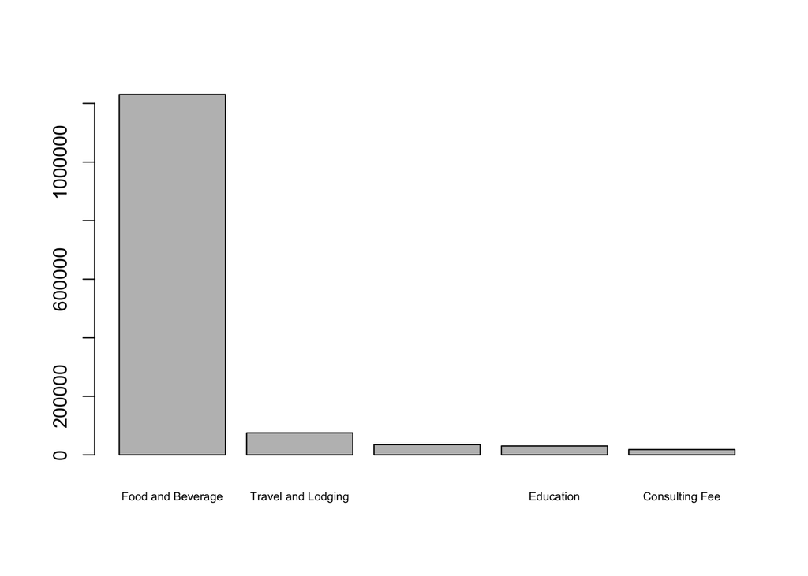

```r
# plotting the top 5 most frequent values of the categorical feature Nature of Payment
barplot(sort(table(payments_df$Nature_of_Payment_or_Transfer_of_Value), decreasing = TRUE)[1:5], cex.names = 0.6)
```

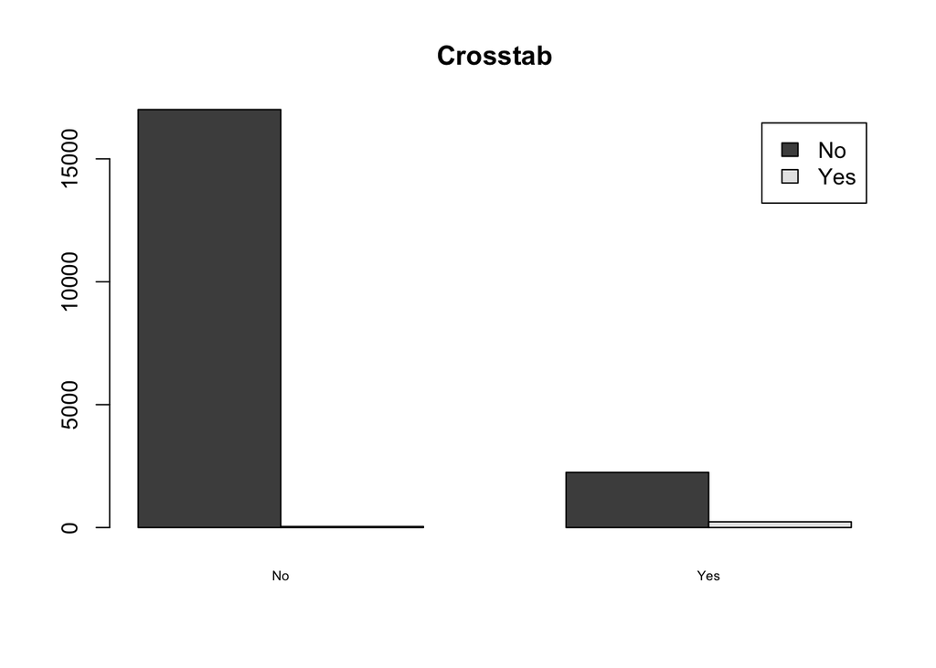

```r
# cross tab plot of ownership interest and certain features with legend
# cex.names: expansion factor for the axis labels
barplot(with(payments_df, table(Ownership_Indicator, Third_Party_Covered)), beside = TRUE, legend.text = TRUE, main = "Crosstab", cex.names = 0.6)
```

```r
# example one hot ecoding
set.seed(555)
data <- data.frame(
  Outcome = seq(1,100,by=1),
  Variable = sample(c("Red","Green","Blue"), 100, replace = TRUE)
)


newdata <- one_hot(as.data.table(data))

newdata
```

| Outcome | Variable_Blue | Variable_Green | Variable_Red |
| --- | --- | --- | --- |
| 1 | 0 | 1 | 0 |
| 2 | 0 | 0 | 1 |
| 3 | 0 | 0 | 1 |
| 4 | 0 | 0 | 1 |
| 5 | 0 | 0 | 1 |
| 6 | 0 | 0 | 1 |
| 7 | 0 | 1 | 0 |
| 8 | 0 | 1 | 0 |
| 9 | 0 | 0 | 1 |
| 10 | 0 | 1 | 0 |

[output cut: 90 more lines]

```r
# PCA attempt

trainset <- select(payments_df, where(is.numeric))

str(trainset)
```

```
## tibble [1,402,250 × 5] (S3: tbl_df/tbl/data.frame)
##  $ Record_ID                        : num [1:1402250] 1 2 3 4 5 6 7 8 9 10 ...
##  $ Physician_ID                     : num [1:1402250] 2455 1534 2632 550 1710 ...
##  $ Company_ID                       : num [1:1402250] 597 593 760 760 826 145 115 897 115 74 ...
##  $ Total_Amount_of_Payment_USDollars: num [1:1402250] 48.8 122.4 10.3 13.7 17.2 ...
##  $ Number_of_Payments               : num [1:1402250] 1 1 1 1 1 1 1 1 1 1 ...
##  - attr(*, "problems")= tibble [1,056,764 × 5] (S3: tbl_df/tbl/data.frame)
##   ..$ row     : int [1:1056764] 531058 531059 531059 531060 531062 531063 531063 531064 531064 531065 ...
##   ..$ col     : chr [1:1056764] "Product_Category_1" "Product_Category_1" "Product_Category_2" "Product_Category_1" ...
##   ..$ expected: chr [1:1056764] "1/0/T/F/TRUE/FALSE" "1/0/T/F/TRUE/FALSE" "1/0/T/F/TRUE/FALSE" "1/0/T/F/TRUE/FALSE" ...
##   ..$ actual  : chr [1:1056764] "OPHTHALMOLOGY" "Orthopaedics" "Orthopaedics" "Electromedical and Electrotherapeutic Apparatus" ...
##   ..$ file    : chr [1:1056764] "'payments.csv'" "'payments.csv'" "'payments.csv'" "'payments.csv'" ...
```

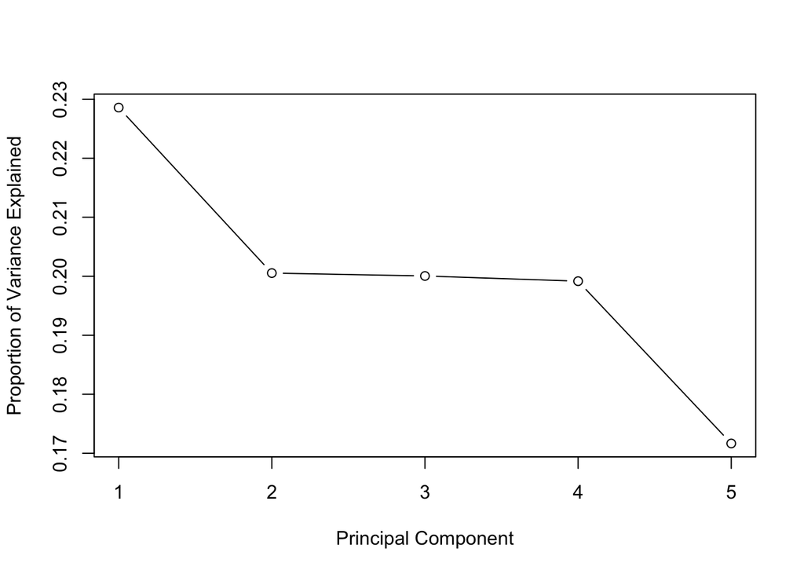

```r
# PCA
pca_trainset = trainset
#pca_testset = testset
pca = prcomp( pca_trainset, scale = T )

# variance
pr_var = ( pca$sdev )^2

# % of variance
prop_varex = pr_var / sum( pr_var )

# Plot (proportion of variance explained by principal component)
plot( prop_varex, xlab = "Principal Component",
                  ylab = "Proportion of Variance Explained", type = "b" )
```

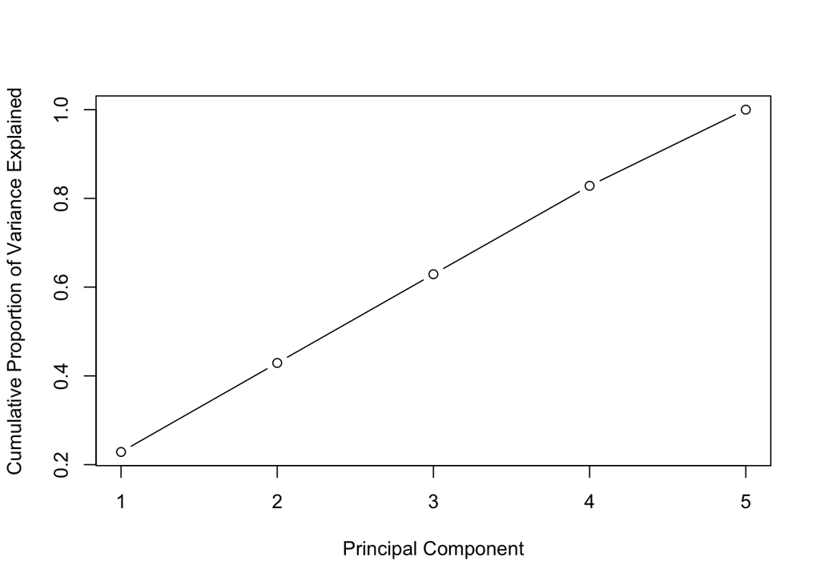

```r
# cummulative variance explained plot
plot( cumsum( prop_varex ), xlab = "Principal Component",
                            ylab = "Cumulative Proportion of Variance Explained", type = "b" )
```

```r
unique(payments_df$Ownership_Indicator)
```

```
## [1] "No"  "Yes"
```

```r
unique(payments_df$Nature_of_Payment_or_Transfer_of_Value)
```

```
##  [1] "Food and Beverage"
##  [2] "Education"
##  [3] "Consulting Fee"
##  [4] "Compensation for services other than consulting, including serving as faculty or as a speaker at a venue other than a continuing education program"
##  [5] "Gift"
##  [6] "Entertainment"
##  [7] "Travel and Lodging"
##  [8] "Compensation for serving as faculty or as a speaker for a non-accredited and noncertified continuing education program"
##  [9] "Royalty or License"
## [10] "Honoraria"
## [11] "Grant"
## [12] "Current or prospective ownership or investment interest"
## [13] "Compensation for serving as faculty or as a speaker for an accredited or certified continuing education program"
## [14] "Charitable Contribution"
```

```r
# for loop which returns all unique values of each feature in the payments df
for (i in (1:length(payments_df))) {
 print(unique(payments_df[i]))
}
```

[output not shown]

[output cut: 271 more lines]

```
## 10 Synalar TS Kit 90
## # … with 2,010 more rows
## # A tibble: 2 x 1
##   Product_Category_1
##   <lgl>
## 1 NA
## 2 TRUE
## # A tibble: 1 x 1
##   Product_Category_2
##   <lgl>
## 1 NA
## # A tibble: 1 x 1
##   Product_Category_3
##   <lgl>
## 1 NA
```

```r
# finding the number of NA values by column in the payments df
payments_df %>% mutate_all(is.na) %>% summarize_all(sum)
```

| Record_ID | Physician_ID | Company_ID | Total_Amount_of_Payment_USDollars | Date | Number_of_Payments | Form_of_Payment_or_Transfer_of_Value | Nature_of_Payment_or_Transfer_of_Value | City_of_Travel | State_of_Travel | Country_of_Travel | Ownership_Indicator | Third_Party_Recipient | Charity | Third_Party_Covered | Contextual_Information | Related_Product_Indicator | Product_Code_1 | Product_Code_2 | Product_Code_3 | Product_Type_1 | Product_Type_2 | Product_Type_3 | Product_Name_1 | Product_Name_2 | Product_Name_3 | Product_Category_1 | Product_Category_2 | Product_Category_3 |
| --- | --- | --- | --- | --- | --- | --- | --- | --- | --- | --- | --- | --- | --- | --- | --- | --- | --- | --- | --- | --- | --- | --- | --- | --- | --- | --- | --- | --- |
| 0 | 0 | 0 | 0 | 0 | 0 | 0 | 0 | 1327122 | 1329446 | 1327122 | 0 | 0 | 634721 | 1382718 | 1245214 | 0 | 384632 | 1142187 | 1318686 | 86193 | 1102362 | 1299751 | 87900 | 1102333 | 1299710 | 1401948 | 1402250 | 1402250 |

```r
summary(payments_df)
```

```
##    Record_ID        Physician_ID    Company_ID
##  Min.   :      1   Min.   :   1   Min.   :   1.0
##  1st Qu.: 350563   1st Qu.:1474   1st Qu.: 114.0
##  Median : 701126   Median :3037   Median : 197.0
##  Mean   : 701126   Mean   :3005   Mean   : 388.1
##  3rd Qu.:1051688   3rd Qu.:4528   3rd Qu.: 473.0
##  Max.   :1402250   Max.   :6000   Max.   :2431.0
##  Total_Amount_of_Payment_USDollars     Date           Number_of_Payments
##  Min.   :       0                  Length:1402250     Min.   :  1.000
##  1st Qu.:      11                  Class :character   1st Qu.:  1.000
##  Median :      15                  Mode  :character   Median :  1.000
##  Mean   :     181                                     Mean   :  1.024
##  3rd Qu.:      23                                     3rd Qu.:  1.000
##  Max.   :10964989                                     Max.   :322.000
##  Form_of_Payment_or_Transfer_of_Value Nature_of_Payment_or_Transfer_of_Value
##  Length:1402250                       Length:1402250
##  Class :character                     Class :character
##  Mode  :character                     Mode  :character
##
##
##
##  City_of_Travel     State_of_Travel    Country_of_Travel  Ownership_Indicator
##  Length:1402250     Length:1402250     Length:1402250     Length:1402250
##  Class :character   Class :character   Class :character   Class :character
##  Mode  :character   Mode  :character   Mode  :character   Mode  :character
##
##
##
##  Third_Party_Recipient   Charity          Third_Party_Covered
##  Length:1402250        Length:1402250     Length:1402250
##  Class :character      Class :character   Class :character
##  Mode  :character      Mode  :character   Mode  :character
##
##
##
##  Contextual_Information Related_Product_Indicator Product_Code_1
##  Length:1402250         Length:1402250            Length:1402250
##  Class :character       Class :character          Class :character
##  Mode  :character       Mode  :character          Mode  :character
##
```

[output cut: 8 more lines]

```
##
##  Product_Type_3     Product_Name_1     Product_Name_2     Product_Name_3
##  Length:1402250     Length:1402250     Length:1402250     Length:1402250
##  Class :character   Class :character   Class :character   Class :character
##  Mode  :character   Mode  :character   Mode  :character   Mode  :character
##
##
##
##  Product_Category_1 Product_Category_2 Product_Category_3
##  Mode:logical       Mode:logical       Mode:logical
##  TRUE:302           NA's:1402250       NA's:1402250
##  NA's:1401948
##
##
##
```

## companies dataframe

```r
companies_df <- read_delim("companies.csv", delim = ",")
str(companies_df)
```

```
## tibble [2,431 × 4] (S3: spec_tbl_df/tbl_df/tbl/data.frame)
##  $ Company_ID: num [1:2431] 1 2 3 4 5 6 7 8 9 10 ...
##  $ Name      : chr [1:2431] "Merck Sharp & Dohme Corporation" "COMSORT, Inc" "Daiichi Sankyo Company LTD" "C. R. Bard, Inc. & Subsidiaries" ...
##  $ State     : chr [1:2431] "NJ" "MD" NA "NJ" ...
##  $ Country   : chr [1:2431] "United States" "United States" "Japan" "United States" ...
##  - attr(*, "spec")=
##   .. cols(
##   ..   Company_ID = col_double(),
##   ..   Name = col_character(),
##   ..   State = col_character(),
##   ..   Country = col_character()
##   .. )
```

```r
# renaming columns in the company df; rename(df_name, new_col_name = old_col_name)
companies_df <- rename(companies_df, c(Company_name = Name, Company_state = State))

str(companies_df)
```

```
## tibble [2,431 × 4] (S3: spec_tbl_df/tbl_df/tbl/data.frame)
##  $ Company_ID   : num [1:2431] 1 2 3 4 5 6 7 8 9 10 ...
##  $ Company_name : chr [1:2431] "Merck Sharp & Dohme Corporation" "COMSORT, Inc" "Daiichi Sankyo Company LTD" "C. R. Bard, Inc. & Subsidiaries" ...
##  $ Company_state: chr [1:2431] "NJ" "MD" NA "NJ" ...
##  $ Country      : chr [1:2431] "United States" "United States" "Japan" "United States" ...
##  - attr(*, "spec")=
##   .. cols(
##   ..   Company_ID = col_double(),
##   ..   Name = col_character(),
##   ..   State = col_character(),
##   ..   Country = col_character()
##   .. )
```

```r
# uploading the markdown file to gdrive
##drive_upload("eda.html")
```

*Merging 2 dataframes by a common column*

```r
# renaming the id column in the physicians_df
# renaming a column way 1 using a base R function
##names(physicians_df)["id"] <- "Physician_ID"

# renaming a column way 2 using the dplyr function rename() and updating the dataframe
physicians_df <- rename(physicians_df,  Physician_ID = id)

colnames(physicians_df)
```

```
##  [1] "Physician_ID"      "set"               "First_Name"
##  [4] "Middle_Name"       "Last_Name"         "Name_Suffix"
##  [7] "City"              "State"             "Zipcode"
## [10] "Country"           "Province"          "Primary_Specialty"
## [13] "License_State_1"   "License_State_2"   "License_State_3"
## [16] "License_State_4"   "License_State_5"
```

```r
# joining the new payments_df and companies_df by Company_ID
df <- merge(payments_df, companies_df, by="Company_ID")

# joining physicians_df and payments_df by Physician_ID using merge()
df_full <- merge(physicians_df, df, by="Physician_ID", all=T)

length(df_full$Ownership_Indicator)
```

```
## [1] 1402250
```

```r
length(df_full$Company_name)
```

```
## [1] 1402250
```

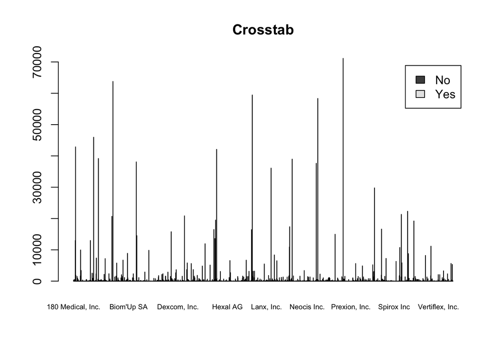

```r
#str(df_full)



#barplot(table(df_full$Ownership_Indicator, df_full$Company_name))

# cross tab plot of ownership interest and certain features with legend
# cex.names: expansion factor for the axis labels
barplot(with(df_full, table(Ownership_Indicator, Company_name)), beside = TRUE, legend.text = TRUE, main = "Crosstab", cex.names = 0.6)
```